# Assignment 1

EDA for Cleveland Heart Disease

## Introduction

**Cleveland Heart Disease Dataset**

- The original source of this dataset is from the [UC Irvine Repository](https://archive.ics.uci.edu/ml/datasets/Heart+Disease)

Heart disease also known as Cardiovascular disease refers to a range of conditions that affect your heart. Heart diseases may include blood vessel diseases, such as coronary artery disease, heart rhythm problems (arrhythmias) and heart defects you’re born with (congenital heart defects), among others.

Heart disease is one of the biggest causes of morbidity and mortality among the population of the world. As a result, there is significant amount of research into this area and the corresponding amount of data is substantial. Data mining / machine learning makes it possible to turn these large collections of healthcare data into insights that can help improve healthcare decisions and treatments. In this practice assignment, we will be using the Cleveland Heart Disease Dataset to do some exploratory data analysis. In the machine learning section of this course, we will start to do simple prediction of cardiovascular disease.

## Dataset

The dataset consists of 303 individuals data. There are 14 columns in the dataset.

- `age` - Age of the individuals in the research
- `sex` - Gender of the individual
- `chest_pain_type` - Type of chest-pain experienced by the individual (1 for typical angina, 2 for atypical angina, 3 for non-anginal pain, 4 for asymptotic)
- `resting_blood_pressure` - Resting blood pressure value of an individual in mmHg
- `serum_cholestrol` - Serum cholesterol in mg/dl
- `fasting_blood_sugar` - Compares the fasting blood sugar value of an individual with 120mg/dl. TRUE if fasting blood sugar > 120mg/dl, FALSE if other wise
- `resting_ecg`- Resting electrocardiographic results
- `max_heart_rate_achieved` - Max heart rate achieved by an individual
- `exercise_induced_angina` - Exercised Induced angina (TRUE or FALSE)
- `st_depression` - ST depression induced by exercise relative to rest
- `peak_exercise_st` - Peak exercise ST segment (downsloping, flat or upsloping)
- `num_color_vessels` - Number of major vessels (0–3) colored by flourosopy
- `thal` - Displays the thalassemia (normal, fixed defect, reversible defect)
- `heart_disease` - Diagnosis of heart disease (absent or present)

## Exercise

- Load Libraries & [Dataset](https://github.com/gl2668/R_For_Data_Science/blob/master/data/heart_disease.rds)
- Provide Descriptive Statistics of the dataset
  - print head
  - print dimensions
  - print summary
- Which variables are Boolean, Discrete or Continuous?
- Plot the Distribution for `age`, `heart_disease` and `resting_blood_pressure`
- What is the mean and median `age` of participants in this research?
- Is there a difference in the average `age` of participants with or without heart disease? What about the `num_color_vessels`?
- Describe the skew and kurtosis of `resting_blood_pressure`
- Create a boxplot between `heart_disease` and `max_heart_rate_achieved`
- Now try plotting the 2 variables with `geom_freqpoly` - What did you noticed?
- Are there any missing data in this dataset?

**Bonus**: Try creating a dodge bar plot like this. Google the `melt()` function.

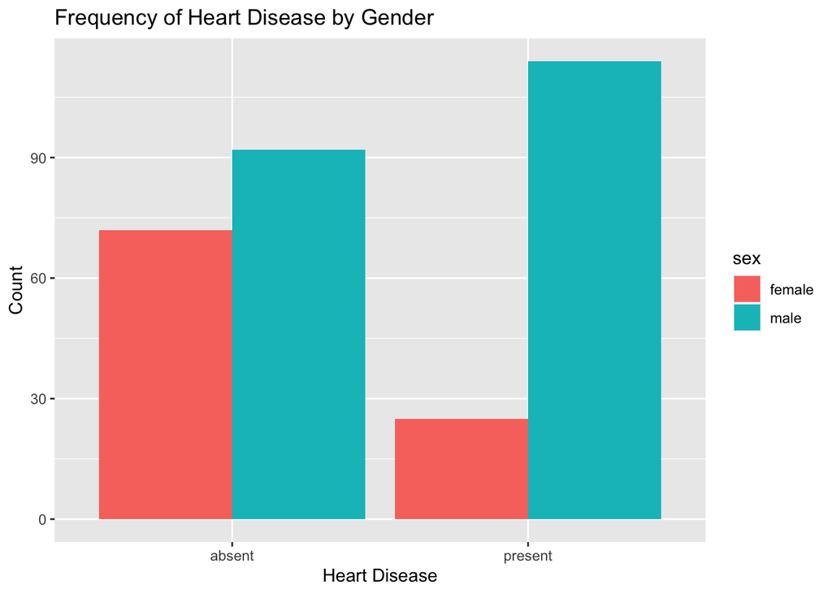

**Bonus**: Clean / Wrangle the data

- Recode the data into numerical format, which would help with analysis
  - Recode `sex` from Male to 1 and Female to 0
  - Recode `fasting_blood_sugar` from TRUE to 1 and FALSE to 0
  - Recode `exercise_induced_angina` from TRUE to 1 and FALSE to 0
  - Recode `thal` from ‘normal’ to 0, ‘fixed defect’ to 1 and ‘reversible defect’ to 2
  - Recode `resting_ecg` from ‘normal’ to 0, ‘ST-T wave abnormality’ to 1 and ‘left ventricular hyperthrophy’ to 2
  - Recode `peak_exercise_st` from ‘upsloping’ to 0, ‘flat’ to 1 and ‘downsloping’ to 2
  - Recode `heart_disease` from ‘present’ to 1 and ‘absent’ to 0

```r
# Example
recode(data$sex, "male" = 1, "female" = 0)
```

## Appendix

Detailed explanation of variables from [Shubhankar Rawat](https://towardsdatascience.com/heart-disease-prediction-73468d630cfc)

1. `Age`: Age is the most important risk factor in developing cardiovascular or heart diseases, with approximately a tripling of risk with each decade of life. Coronary fatty streaks can begin to form in adolescence. It is estimated that 82 percent of people who die of coronary heart disease are 65 and older. Simultaneously, the risk of stroke doubles every decade after age 55.
2. `Sex`: Men are at greater risk of heart disease than pre-menopausal women. Once past menopause, it has been argued that a woman’s risk is similar to a man’s although more recent data from the WHO and UN disputes this. If a female has diabetes, she is more likely to develop heart disease than a male with diabetes.
3. `Angina (Chest Pain)`: Angina is chest pain or discomfort caused when your heart muscle doesn’t get enough oxygen-rich blood. It may feel like pressure or squeezing in your chest. The discomfort also can occur in your shoulders, arms, neck, jaw, or back. Angina pain may even feel like indigestion.
4. `Resting Blood Pressure`: Over time, high blood pressure can damage arteries that feed your heart. High blood pressure that occurs with other conditions, such as obesity, high cholesterol or diabetes, increases your risk even more.
5. `Serum Cholesterol`: A high level of low-density lipoprotein (LDL) cholesterol (the “bad” cholesterol) is most likely to narrow arteries. A high level of triglycerides, a type of blood fat related to your diet, also ups your risk of a heart attack. However, a high level of high-density lipoprotein (HDL) cholesterol (the “good” cholesterol) lowers your risk of a heart attack.
6. `Fasting Blood Sugar`: Not producing enough of a hormone secreted by your pancreas (insulin) or not responding to insulin properly causes your body’s blood sugar levels to rise, increasing your risk of a heart attack.
7. `Resting ECG`: For people at low risk of cardiovascular disease, the USPSTF concludes with moderate certainty that the potential harms of screening with resting or exercise ECG equal or exceed the potential benefits. For people at intermediate to high risk, current evidence is insufficient to assess the balance of benefits and harms of screening.
8. `Max heart rate achieved`: The increase in cardiovascular risk, associated with the acceleration of heart rate, was comparable to the increase in risk observed with high blood pressure. It has been shown that an increase in heart rate by 10 beats per minute was associated with an increase in the risk of cardiac death by at least 20%, and this increase in the risk is similar to the one observed with an increase in systolic blood pressure by 10 mm Hg.
9. `Exercise induced angina`: The pain or discomfort associated with angina usually feels tight, gripping or squeezing, and can vary from mild to severe. Angina is usually felt in the center of your chest but may spread to either or both of your shoulders, or your back, neck, jaw or arm. It can even be felt in your hands. o Types of Angina a. Stable Angina / Angina Pectoris b. Unstable Angina c. Variant (Prinzmetal) Angina d. Microvascular Angina.
10. `Peak exercise ST segment`: A treadmill ECG stress test is considered abnormal when there is a horizontal or down-sloping ST-segment depression ≥ 1 mm at 60–80 ms after the J point. Exercise ECGs with up-sloping ST-segment depressions are typically reported as an ‘equivocal’ test. In general, the occurrence of horizontal or down-sloping ST-segment depression at a lower workload (calculated in METs) or heart rate indicates a worse prognosis and higher likelihood of multi-vessel disease. The duration of ST-segment depression is also important, as prolonged recovery after peak stress is consistent with a positive treadmill ECG stress test. Another finding that is highly indicative of significant CAD is the occurrence of ST-segment elevation > 1 mm (often suggesting transmural ischemia); these patients are frequently referred urgently for coronary angiography.